# Bad Bunny

Author

Céleste Orsel

# Bad Bunny or “The King of Latin Trap”

### Who’s Bad Bunny?

Benito Antonio Martínez Ocasio, known as Bad Bunny, was born in 1994, in Vega Baja, Puerto Rico. He is known worldwide for his songs, mixing Latin trap with reggaeton and from times to times adding a bit rock, bachata, or salsa. You probably know him as he was the most-streamed artist on Spotify for three consecutive years (2020–2022) and was the first solo Latin artist to headline the Super Bowl (LX), mostly in Spanish in early 2026.

Benito uses his music as a platform not only for entertainment but also for political expression. His work promotes human rights, draws attention to social and political issues in Puerto Rico, and celebrates Puerto Rican culture and traditions. With the release of his last album, he went a step further in supporting Puerto Rico by doing a 30-date residency there. The concerts attracted thousands of tourists who spent more than $200 million on lodging, food, and transportation according to the non-profit DMO Discover Puerto Rico.

## Collaborations

With international artists

- “I like it” - J. Balvin & Cardi B.
- “Mia” - with Drake
- “Ahora Me Llama” - with Carol G.

With local artists

- “PERFuMITO NUEVO” - with RaiNao
- “VeLDÁ” - with Dei V
- “WELTiTA” - Omar Courtz, and indie group Chuwi

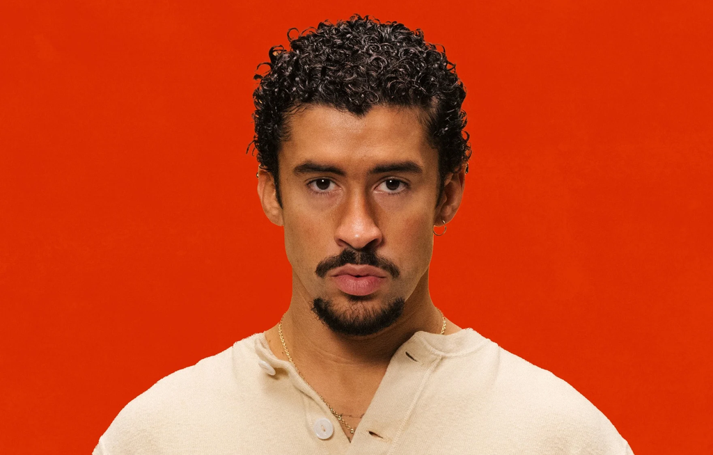

### In case you haven’t seen his performance at the Super Bowl:

[video not shown]

### One quote that we should all remember:

> *The only thing that is more powerful than hate is love.*

> **-- Bad Bunny, Super Bowl half time show**

Following the Super Bowl, the artist Alberto León portrayed Bad Bunny as a symbol of peace and resistance to D. Trump in a street in Barcelona.

[figure not shown]

### Recently, Bad Bunny won quite a few prizes at the Grammy Awards,

- Album of the year: For his album Debí Tirar Más Fotos, it became the first Spanish-language album ever to win the Recording Academy’s top honor.
- Best Música Urbana Album: Also for Debí Tirar Más Fotos.
- Best Global Music Performance: For his track “EoO”.

[video not shown]

### His albums

- Debí Tirar Más Fotos - 2025

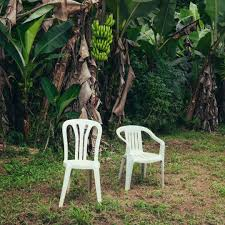

- Nadie Sabe Lo Que Va a Pasar Mañana - 2023

[figure not shown]

- Un Verano Sin Ti - 2022

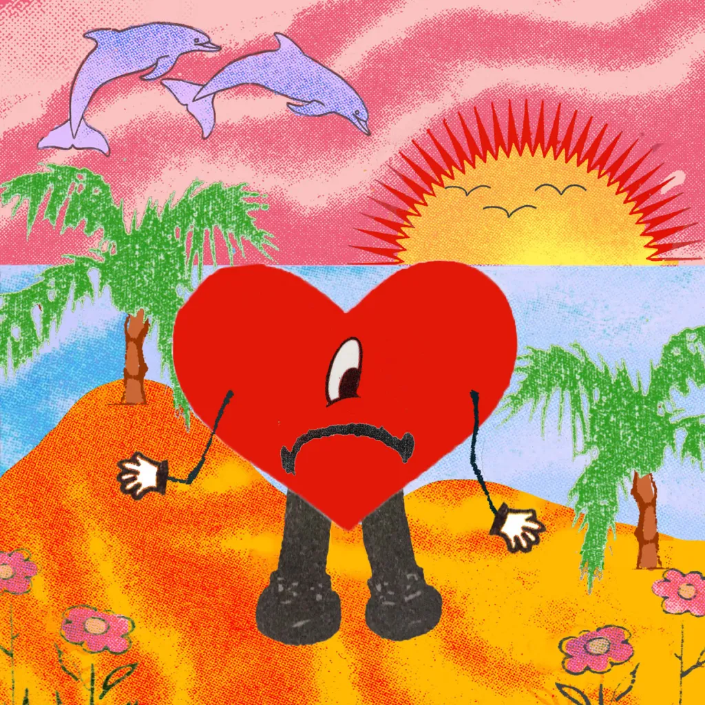

- El Último Tour Del Mundo - 2020

[figure not shown]

- YHLQMDLG - 2020

[figure not shown]

- X 100pre - 2018

[figure not shown]

## Data preparation

```r
library(dplyr)
library(ggplot2)
badbunny_songs <- read.csv("music_analysis_badbunny_test.csv")

#Scatterplot analysis
badbunny_songs$Song <- iconv(badbunny_songs$Song, from = "latin1", to = "UTF-8")
badbunny_songs$Album <- iconv(badbunny_songs$Album, from = "latin1", to = "UTF-8")
```

## Statistical analyses of Bad Bunny’s first and last albums

### Analysis of valence and energy between X 100pre and Debí Tirar Más Fotos

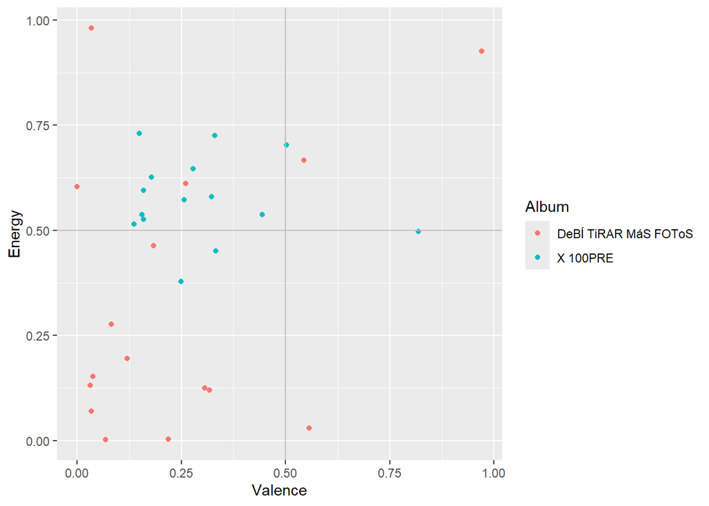

```r
#Packages needed for the analysis

ggplot(badbunny_songs, aes(x = Valence, y = Energy, color = Album))+
  geom_point()+
  geom_hline(yintercept = 0.5, color="grey")+
  geom_vline(xintercept = 0.5, color="grey")
```

### Bad Bunny’s last album is know for incorporating many different musical styles including traditional puertorican music.

Let’s see how the instrumentalness of his songs has changed between his first and last album!

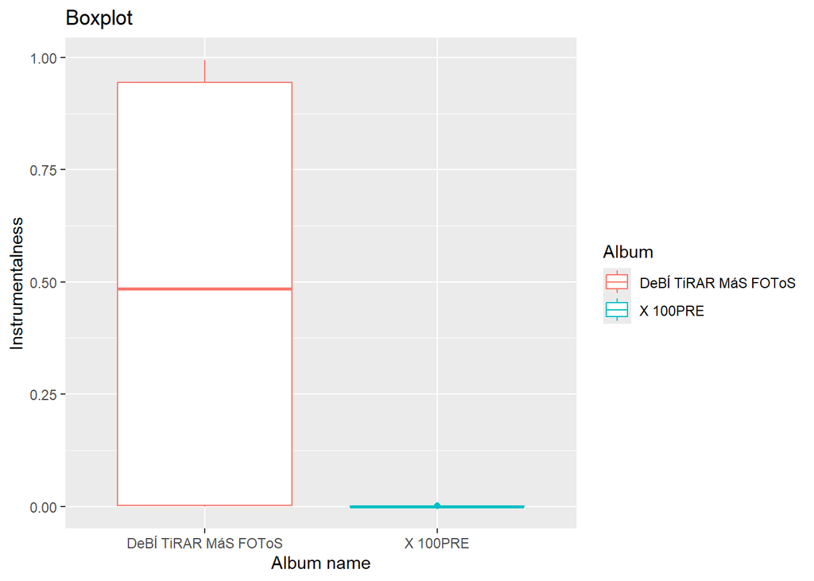

```r
ggplot(badbunny_songs, aes(x=Album, y= Instrumentalness, color=Album))+
  geom_boxplot()+
  labs(title ="Boxplot", x="Album name", y="Instrumentalness")
```

### This scatterplot analyzes the relation between danceability and energy within the two selected albums.

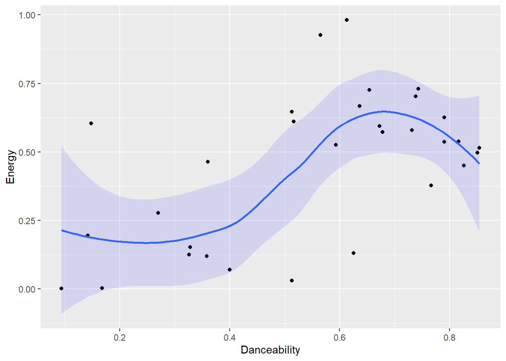

```r
ggplot(badbunny_songs, aes(x = Danceability, y = Energy,))+
  geom_point()+
  geom_smooth(alpha = 0.1, fill="blue")
```

```r
badbunny_songs |> slice_max(Danceability, n = 3, with_ties = FALSE) |> select(Song, Album, Danceability)
```

```
                Song    Album Danceability
1 Tenemos Que Hablar X 100PRE        0.854
2            200 Mph X 100PRE        0.850
3     NI BIEN NI MAL X 100PRE        0.826
```

Looks like the relationship between the two variables is not very linear… but if you still wanna dance, you should probably listen to “*Tenemos que hablar”* from the album X 100pre !

[video not shown]

However, my personal recommendation would still be “*VeLDA”* if you want a good song to dance!

[video not shown]

## Conclusion

This website on the artist Bad Bunny aims at introducing his work to a broader audience but also share the specificities of his music and highlight the message he wants to convey.

Regarding the statistical analysis comparing his first and last albums some of the results were surprising. His last album has low energy and valence levels although I would not consider it to be sad, it relays important messages but also includes very joyful music types such as salsa, bachata or reggaeton. Similarly, the analysis of Bad Bunny’s supposedly most danceable song, “Tenemos Que Hablar” was quite deceiving.

Therefore, what we can take from this analysis is that music has maybe more to do with personal feeling than with data !